# About the Data

The dataset contains information on three species of iris flowers: Iris setosa, Iris versicolor, and Iris virginica.

It includes measurements of four features: sepal length, sepal width, petal length, and petal width.

Each row represents a single flower, with measurements given in centimeters.

The dataset consists of 150 samples — 50 for each species.

Columns

- **sepal length** – length of the sepal in cm
- **sepal width** – width of the sepal in cm
- **petal length** – length of the petal in cm
- **petal width** – width of the petal in cm
- **class – species** of the iris (setosa, versicolor, virginica)

|  | długość kielicha (sepal length) | szerokość kielicha (sepal width) | długość płatka (petal length) | szerokość płatka (petal width) | klasa (class) |
| --- | --- | --- | --- | --- | --- |
| 0 | 5.1 | 3.5 | 1.4 | 0.2 | Iris-setosa |
| 1 | 4.9 | 3.0 | 1.4 | 0.2 | Iris-setosa |
| 2 | 4.7 | 3.2 | 1.3 | 0.2 | Iris-setosa |
| 3 | 4.6 | 3.1 | 1.5 | 0.2 | Iris-setosa |
| 4 | 5.0 | 3.6 | 1.4 | 0.2 | Iris-setosa |
| ... | ... | ... | ... | ... | ... |
| 145 | 6.7 | 3.0 | 5.2 | 2.3 | Iris-virginica |
| 146 | 6.3 | 2.5 | 5.0 | 1.9 | Iris-virginica |
| 147 | 6.5 | 3.0 | 5.2 | 2.0 | Iris-virginica |
| 148 | 6.2 | 3.4 | 5.4 | 2.3 | Iris-virginica |
| 149 | 5.9 | 3.0 | 5.1 | 1.8 | Iris-virginica |

150 rows × 5 columns

# Basic Data Analysis

|  | długość kielicha (sepal length) | szerokość kielicha (sepal width) | długość płatka (petal length) | szerokość płatka (petal width) | klasa (class) |
| --- | --- | --- | --- | --- | --- |
| 5 | 5.4 | 3.9 | 1.7 | 0.4 | Iris-setosa |
| 106 | 4.9 | 2.5 | 4.5 | 1.7 | Iris-virginica |
| 28 | 5.2 | 3.4 | 1.4 | 0.2 | Iris-setosa |
| 142 | 5.8 | 2.7 | 5.1 | 1.9 | Iris-virginica |
| 53 | 5.5 | 2.3 | 4.0 | 1.3 | Iris-versicolor |
| 71 | 6.1 | 2.8 | 4.0 | 1.3 | Iris-versicolor |
| 42 | 4.4 | 3.2 | 1.3 | 0.2 | Iris-setosa |
| 83 | 6.0 | 2.7 | 5.1 | 1.6 | Iris-versicolor |
| 34 | 4.9 | 3.1 | 1.5 | 0.1 | Iris-setosa |
| 69 | 5.6 | 2.5 | 3.9 | 1.1 | Iris-versicolor |
| 52 | 6.9 | 3.1 | 4.9 | 1.5 | Iris-versicolor |
| 85 | 6.0 | 3.4 | 4.5 | 1.6 | Iris-versicolor |
| 75 | 6.6 | 3.0 | 4.4 | 1.4 | Iris-versicolor |
| 25 | 5.0 | 3.0 | 1.6 | 0.2 | Iris-setosa |
| 120 | 6.9 | 3.2 | 5.7 | 2.3 | Iris-virginica |
| 143 | 6.8 | 3.2 | 5.9 | 2.3 | Iris-virginica |
| 145 | 6.7 | 3.0 | 5.2 | 2.3 | Iris-virginica |
| 74 | 6.4 | 2.9 | 4.3 | 1.3 | Iris-versicolor |
| 138 | 6.0 | 3.0 | 4.8 | 1.8 | Iris-virginica |
| 3 | 4.6 | 3.1 | 1.5 | 0.2 | Iris-setosa |

Unique measurements

```
długość kielicha (sepal length)     35
szerokość kielicha (sepal width)    23
długość płatka (petal length)       43
szerokość płatka (petal width)      22
klasa (class)                        3
dtype: int64
```

|  | długość kielicha (sepal length) | szerokość kielicha (sepal width) | długość płatka (petal length) | szerokość płatka (petal width) | klasa (class) |
| --- | --- | --- | --- | --- | --- |
| 34 | 4.9 | 3.1 | 1.5 | 0.1 | Iris-setosa |
| 37 | 4.9 | 3.1 | 1.5 | 0.1 | Iris-setosa |
| 142 | 5.8 | 2.7 | 5.1 | 1.9 | Iris-virginica |

|  | długość kielicha (sepal length) | szerokość kielicha (sepal width) | długość płatka (petal length) | szerokość płatka (petal width) |
| --- | --- | --- | --- | --- |
| count | 150.000000 | 150.000000 | 150.000000 | 150.000000 |
| mean | 5.843333 | 3.054000 | 3.758667 | 1.198667 |
| std | 0.828066 | 0.433594 | 1.764420 | 0.763161 |
| min | 4.300000 | 2.000000 | 1.000000 | 0.100000 |
| 25% | 5.100000 | 2.800000 | 1.600000 | 0.300000 |
| 50% | 5.800000 | 3.000000 | 4.350000 | 1.300000 |
| 75% | 6.400000 | 3.300000 | 5.100000 | 1.800000 |
| max | 7.900000 | 4.400000 | 6.900000 | 2.500000 |

A preliminary review shows that the size of the flowers across the three species varies by only a few centimeters. The most typical values for the dataset as a whole are:

- Sepal length: ~ 5.8 cm
- Sepal width: ~ 3.0 cm
- Petal length: ~ 4.3 cm
- Petal width: ~ 1.3 cm

It is also relatively rare for two flowers to have exactly the same combination of measurements.

# Species-Level Analysis

## Iris setosa

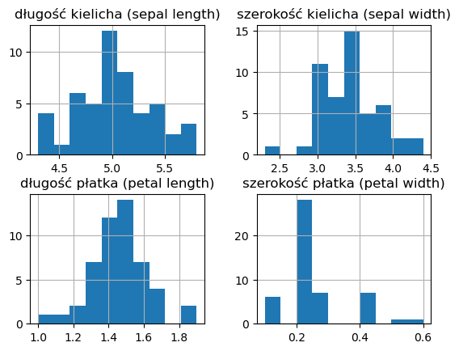

|  | długość kielicha (sepal length) | szerokość kielicha (sepal width) | długość płatka (petal length) | szerokość płatka (petal width) |
| --- | --- | --- | --- | --- |
| count | 50.00000 | 50.000000 | 50.000000 | 50.00000 |
| mean | 5.00600 | 3.418000 | 1.464000 | 0.24400 |
| std | 0.35249 | 0.381024 | 0.173511 | 0.10721 |
| min | 4.30000 | 2.300000 | 1.000000 | 0.10000 |
| 25% | 4.80000 | 3.125000 | 1.400000 | 0.20000 |
| 50% | 5.00000 | 3.400000 | 1.500000 | 0.20000 |
| 75% | 5.20000 | 3.675000 | 1.575000 | 0.30000 |
| max | 5.80000 | 4.400000 | 1.900000 | 0.60000 |

**Average Values**

- Sepal length: 5.0 cm
- Sepal width: 3.5 cm
- Petal length: 1.5 cm
- Petal width: 0.2 cm

## Iris versicolor

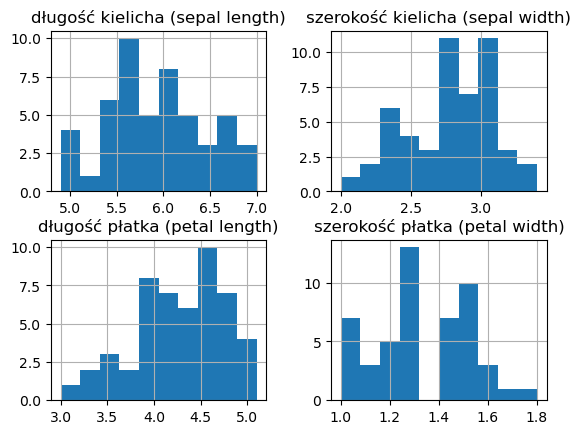

|  | długość kielicha (sepal length) | szerokość kielicha (sepal width) | długość płatka (petal length) | szerokość płatka (petal width) |
| --- | --- | --- | --- | --- |
| count | 50.000000 | 50.000000 | 50.000000 | 50.000000 |
| mean | 5.936000 | 2.770000 | 4.260000 | 1.326000 |
| std | 0.516171 | 0.313798 | 0.469911 | 0.197753 |
| min | 4.900000 | 2.000000 | 3.000000 | 1.000000 |
| 25% | 5.600000 | 2.525000 | 4.000000 | 1.200000 |
| 50% | 5.900000 | 2.800000 | 4.350000 | 1.300000 |
| 75% | 6.300000 | 3.000000 | 4.600000 | 1.500000 |
| max | 7.000000 | 3.400000 | 5.100000 | 1.800000 |

## Iris virginica

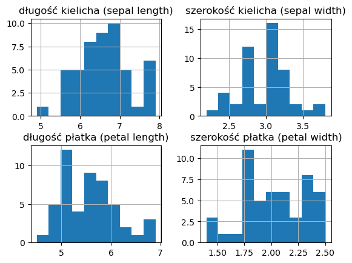

|  | długość kielicha (sepal length) | szerokość kielicha (sepal width) | długość płatka (petal length) | szerokość płatka (petal width) |
| --- | --- | --- | --- | --- |
| count | 50.00000 | 50.000000 | 50.000000 | 50.00000 |
| mean | 6.58800 | 2.974000 | 5.552000 | 2.02600 |
| std | 0.63588 | 0.322497 | 0.551895 | 0.27465 |
| min | 4.90000 | 2.200000 | 4.500000 | 1.40000 |
| 25% | 6.22500 | 2.800000 | 5.100000 | 1.80000 |
| 50% | 6.50000 | 3.000000 | 5.550000 | 2.00000 |
| 75% | 6.90000 | 3.175000 | 5.875000 | 2.30000 |
| max | 7.90000 | 3.800000 | 6.900000 | 2.50000 |

**Average Values**

- Sepal length: 6.5 cm
- Sepal width: 3.0 cm
- Petal length: 5.5 cm
- Petal width: 2.0 cm

# Correlations

|  | długość kielicha (sepal length) | szerokość kielicha (sepal width) | długość płatka (petal length) | szerokość płatka (petal width) |
| --- | --- | --- | --- | --- |
| długość kielicha (sepal length) | 1.000000 | -0.109369 | 0.871754 | 0.817954 |
| szerokość kielicha (sepal width) | -0.109369 | 1.000000 | -0.420516 | -0.356544 |
| długość płatka (petal length) | 0.871754 | -0.420516 | 1.000000 | 0.962757 |
| szerokość płatka (petal width) | 0.817954 | -0.356544 | 0.962757 | 1.000000 |

From the dataset, several relationships can be observed:

- Longer and wider petals are generally associated with longer sepals.
- Petal width has a positive influence on petal length.
- Other correlations are weak and can be ignored.

## Iris setosa

|  | długość kielicha (sepal length) | szerokość kielicha (sepal width) | długość płatka (petal length) | szerokość płatka (petal width) |
| --- | --- | --- | --- | --- |
| długość kielicha (sepal length) | 1.000000 | 0.746780 | 0.263874 | 0.279092 |
| szerokość kielicha (sepal width) | 0.746780 | 1.000000 | 0.176695 | 0.279973 |
| długość płatka (petal length) | 0.263874 | 0.176695 | 1.000000 | 0.306308 |
| szerokość płatka (petal width) | 0.279092 | 0.279973 | 0.306308 | 1.000000 |

## Iris versicolor

|  | długość kielicha (sepal length) | szerokość kielicha (sepal width) | długość płatka (petal length) | szerokość płatka (petal width) |
| --- | --- | --- | --- | --- |
| długość kielicha (sepal length) | 1.000000 | 0.525911 | 0.754049 | 0.546461 |
| szerokość kielicha (sepal width) | 0.525911 | 1.000000 | 0.560522 | 0.663999 |
| długość płatka (petal length) | 0.754049 | 0.560522 | 1.000000 | 0.786668 |
| szerokość płatka (petal width) | 0.546461 | 0.663999 | 0.786668 | 1.000000 |

## Iris virginica

|  | długość kielicha (sepal length) | szerokość kielicha (sepal width) | długość płatka (petal length) | szerokość płatka (petal width) |
| --- | --- | --- | --- | --- |
| długość kielicha (sepal length) | 1.000000 | 0.457228 | 0.864225 | 0.281108 |
| szerokość kielicha (sepal width) | 0.457228 | 1.000000 | 0.401045 | 0.537728 |
| długość płatka (petal length) | 0.864225 | 0.401045 | 1.000000 | 0.322108 |
| szerokość płatka (petal width) | 0.281108 | 0.537728 | 0.322108 | 1.000000 |

**Looking at species individually, there is a general trend: when one feature of the flower is large, the others also tend to be larger.**

# Outliers

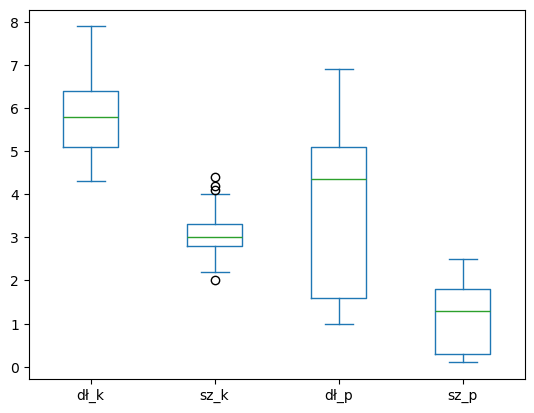

## Iris setosa

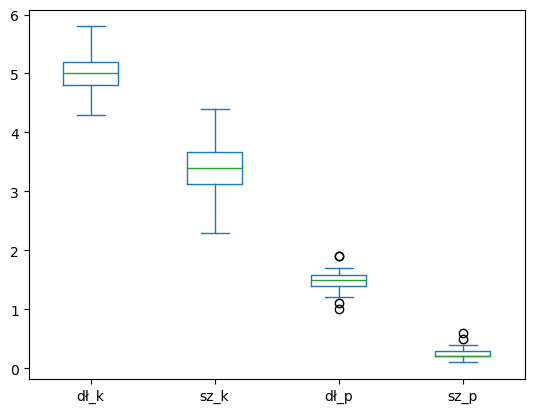

## Iris versicolor

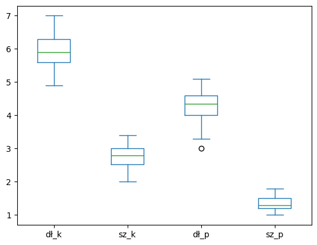

## Iris virginica

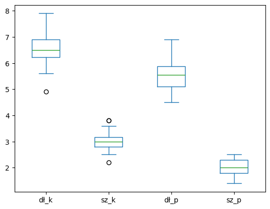

Analysis of the plots shows that the biggest differences between species are in petal length. There are very few outliers, and they do not significantly affect the overall statistics.

# Summary

**Setosa**

- Smallest flowers overall, especially in petal length (1.5 cm).
- Has the widest sepals on average (3.5 cm).

**Virginica**

- Largest species overall, with petal length averaging 5.5 cm.

**Key Insight**

Among the three species, Virginica reaches the largest sizes, while Setosa is the smallest. Versicolor lies in between.

The best way to distinguish the species is by focusing primarily on petal length and petal width, as these provide the clearest separation between classes.